# 16 Neural Networks

Algorithmics 2025

## Neural Networks

In machine learning, a neural network is a computational model inspired by the structure and function of biological neural networks.

A **perceptron** is the simplest form of such a model, representing a single unit of computation.

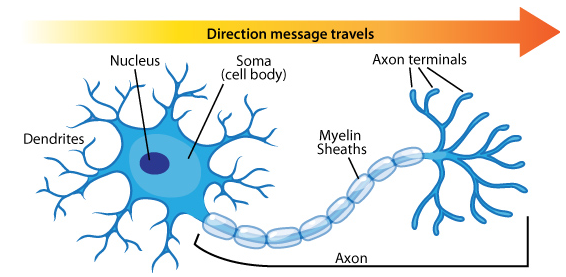

Neuron

## Perceptron

A perceptron is the earliest form of a neural network unit, introduced by Frank Rosenblatt in 1958.  
It is a **binary classifier** that makes predictions based on a linear combination of input features.

**Components:**

- **Inputs**: $(x_1, x_2, \dots, x_n)$
- **Weights**: $(w_1, w_2, \dots, w_n)$ – relative importance of features
- **Bias**: $b$, shifts the decision boundary
- **Activation Function**: step function threshold

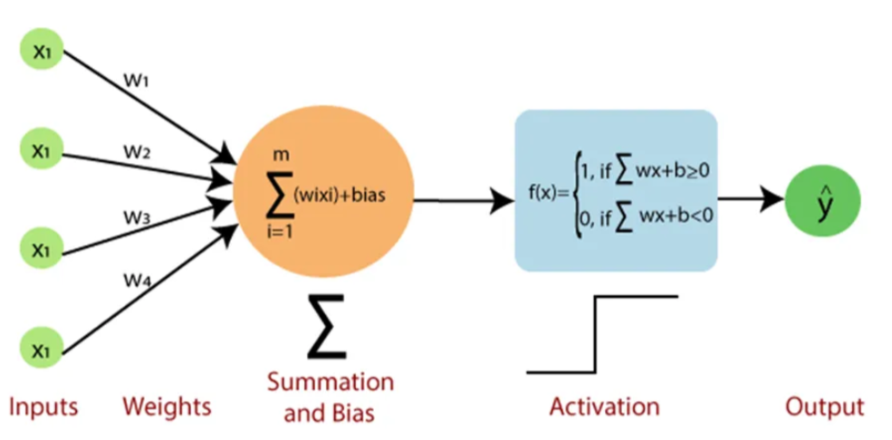

perceptron

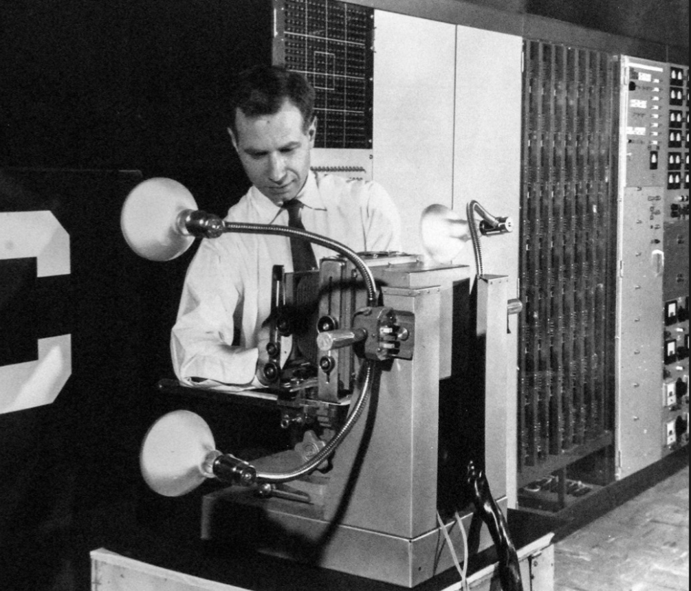

Perceptron

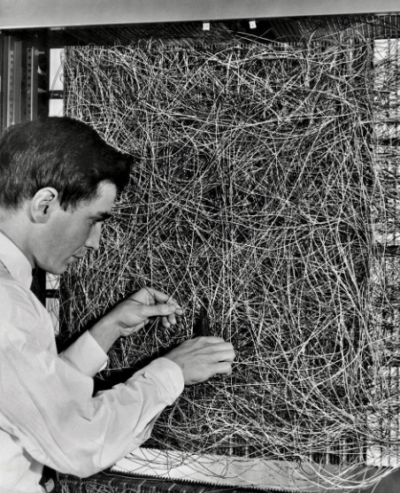

Perceptron

## Perceptron (Mathematics)

y =
$$\begin{cases}
1 & \text{if } \displaystyle \sum_{i=1}^{n} w_i x_i + b > 0 \\
0 & \text{if } \displaystyle \sum_{i=1}^{n} w_i x_i + b \leq 0
\end{cases}$$

## The output is **binary (0 or 1)**, making it suitable for linearly separable classification problems.

## Example: Spam Filter

- We design a perceptron with the following setup:
- $x_1$: number of times the word “free” appears
- $x_2$: whether the email has an attachment (0/1)
- $x_3$: length of the subject line
- Weights: $w_1 = 2,\; w_2 = 3,\; w_3 = -0.5$
- Bias: $b = -4$

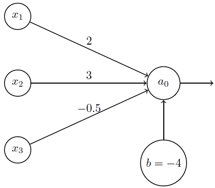

1. Will the perceptron classify an email with $x_1 =3, x_2 = 1 \text{ and } x_3 = 6$ as spam?
2. Which feature is the most important
3. What should the bias be adjusted to so that the email is not classified as spam

[But what is a neural network? 3Blue1Brown](https://youtu.be/aircAruvnKk?si=P9kqjzbaBbg6QQHc)